# Assignment 1: Basic Programming in R

Xindie Huang (20561232)

## I. Simulate Data

1. To simulate data, first make a data frame as follows.

```r
# clear the working environment
rm(list = ls())
library(tibble)
df <- tibble(i = rep(1:1000, each = 2), k = rep(1:2, times = 1000), x = rep(0:1, times = 1000))
df
```

```
## # A tibble: 2,000 x 3
##        i     k     x
##    <int> <int> <int>
##  1     1     1     0
##  2     1     2     1
##  3     2     1     0
##  4     2     2     1
##  5     3     1     0
##  6     3     2     1
##  7     4     1     0
##  8     4     2     1
##  9     5     1     0
## 10     5     2     1
## # ... with 1,990 more rows
```

2. Second, draw type-I extreme value random variables. Set the seed at 1. You can use `evd` package to draw the variables. You should get exactly the same realization if the seed is correctly set.

```r
library(evd)
set.seed(1)
df <- add_column(df, e = rgumbel(n = 2000, loc = 0, scale = 1))
df
```

```
## # A tibble: 2,000 x 4
##        i     k     x       e
##    <int> <int> <int>   <dbl>
##  1     1     1     0  0.281
##  2     1     2     1 -0.167
##  3     2     1     0  1.93
##  4     2     2     1  1.97
##  5     3     1     0  0.830
##  6     3     2     1 -1.06
##  7     4     1     0 -0.207
##  8     4     2     1  0.617
##  9     5     1     0  0.0444
## 10     5     2     1  1.92
## # ... with 1,990 more rows
```

3. Third, compute the latent value of each option to obtain the following data frame:

```r
beta <- 0.2
df <- add_column(df, latent = beta * df$x + df$e)
df
```

```
## # A tibble: 2,000 x 5
##        i     k     x       e  latent
##    <int> <int> <int>   <dbl>   <dbl>
##  1     1     1     0  0.281   0.281
##  2     1     2     1 -0.167   0.0331
##  3     2     1     0  1.93    1.93
##  4     2     2     1  1.97    2.17
##  5     3     1     0  0.830   0.830
##  6     3     2     1 -1.06   -0.863
##  7     4     1     0 -0.207  -0.207
##  8     4     2     1  0.617   0.817
##  9     5     1     0  0.0444  0.0444
## 10     5     2     1  1.92    2.12
## # ... with 1,990 more rows
```

4. Finally, compute $y$ by comparing the latent values of $k=1,2$ for each $i$ to obtain the following result:

```r
df <- add_column(df, y = rep(0, times = 2000))
for (t in 1:1000) {
  ifelse(df$i[2 * t] == df$i[2 * t - 1] && df$latent[2 * t] >= df$latent[2 * t - 1], df$y[2 * t] <- 1, df$y[2 * t - 1] <- 1)
}
rm(t)
df
```

```
## # A tibble: 2,000 x 6
##        i     k     x       e  latent     y
##    <int> <int> <int>   <dbl>   <dbl> <dbl>
##  1     1     1     0  0.281   0.281      1
##  2     1     2     1 -0.167   0.0331     0
##  3     2     1     0  1.93    1.93       0
##  4     2     2     1  1.97    2.17       1
##  5     3     1     0  0.830   0.830      1
##  6     3     2     1 -1.06   -0.863      0
##  7     4     1     0 -0.207  -0.207      0
##  8     4     2     1  0.617   0.817      1
##  9     5     1     0  0.0444  0.0444     0
## 10     5     2     1  1.92    2.12       1
## # ... with 1,990 more rows
```

## II. Estimate the Parameters

1. Write a function to compute the likelihood for a given $\beta$ and data and name the function `loglikelihood_A1`.

```r
source("../R/functions.R") # see details in "R/functions.R"
```

2. Compute the value of log likelihood for $\beta = 0,0.1,...,1$ and plot the result using `ggplot2` packages. You can use `latex2exp` package to use $\LaTeX$ math symbol in the label:

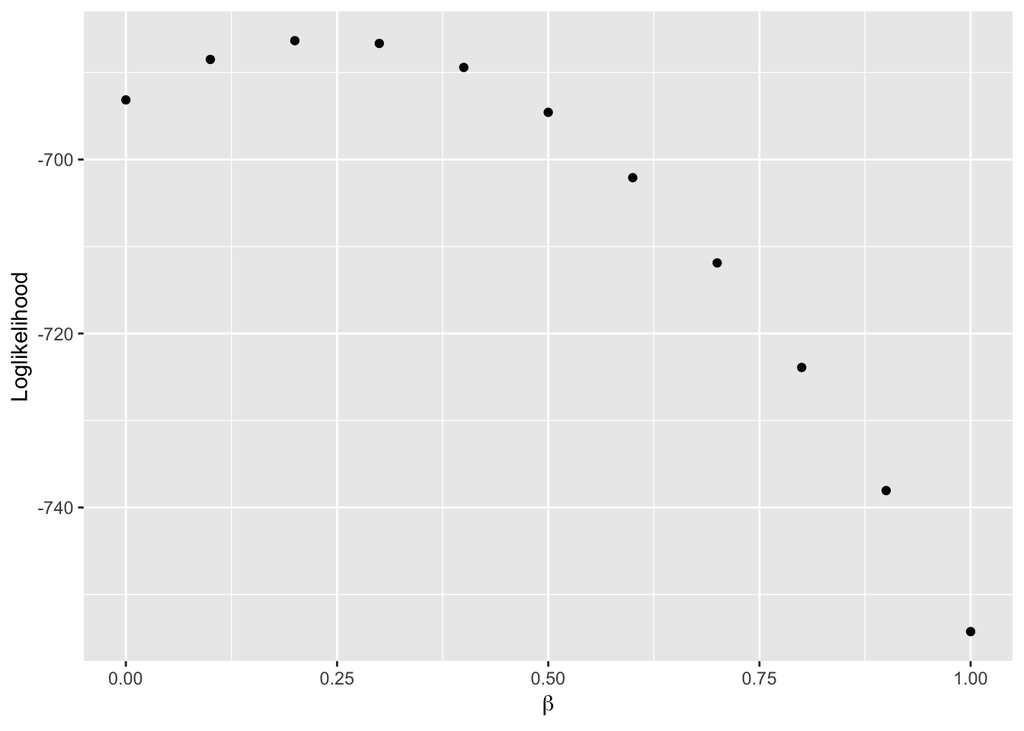

```r
library(ggplot2)
library(latex2exp)
beta <- seq(from = 0, to = 1, by = 0.1)
Loglikelihood <- c()
for (i in 1:length(beta)) {
  Loglikelihood <- c(Loglikelihood, loglikelihood_A1(beta[i], df))
}
qplot(x = beta, y = Loglikelihood, xlab = TeX('$\\beta$'), ylab = "Loglikelihood")
```

3. Find and report $\beta$ that maximizes the log likelihood for the simulated data. You can use `optim` function to achieve this. You will use `Brent` method and set the lower bound at -1 and upper bound at 1 for the parameter search.

```r
optim(par = -1, fn = loglikelihood_A1, data = df, method = "Brent", control = list(fnscale = -1), lower = -1, upper = 1, hessian = FALSE)
```

```
## $par
## [1] 0.2371046
##
## $value
## [1] -686.1689
##
## $counts
## function gradient
##       NA       NA
##
## $convergence
## [1] 0
##
## $message
## NULL
```